# 03 - Simple hypothesis test in R

Francisco E. Fonturbel

March 10, 2026

## Simple hypothesis test in R

Now that we have the basic principles of creating and operating objects in R, as well as making some pretty nice graphics, now let’s get started with statistics in R. Now we will start with some basic hypothesis testing by comparing the means of two or more treatments (groups).

Let’s imagine that we measured the growth of some plants with two treatments: watered with 100 mL per day and watered with 50 mL per day. If there is no effect of the amount of water received, we should expect (i.e., null hypothesis) that the mean height of the plants will be equal:

$\mu {1} = \mu {2}$

And, of course, our alternative hypothesis would be:

$\mu {1} \neq \mu {2}$

## Two groups: *t-test*

As we have only two groups, we can use Student’s *t test* using the `t.test` function included in the R base package.

```r
data<-read.csv("data/03_waterpl.csv", header = TRUE, sep = ";")
attach(data)
```

So, we have a simple dataset containing plant height measurements for two treatments (named A and B).

```r
t.test(height~treatment)
```

```
##
##  Welch Two Sample t-test
##
## data:  height by treatment
## t = -7.6229, df = 96.118, p-value = 1.759e-11
## alternative hypothesis: true difference in means between group A and group B is not equal to 0
## 95 percent confidence interval:
##  -1.816327 -1.065830
## sample estimates:
## mean in group A mean in group B
##        1.973864        3.414943
```

So, it seems that plant height differs, let’s take a look using a simple boxplot:

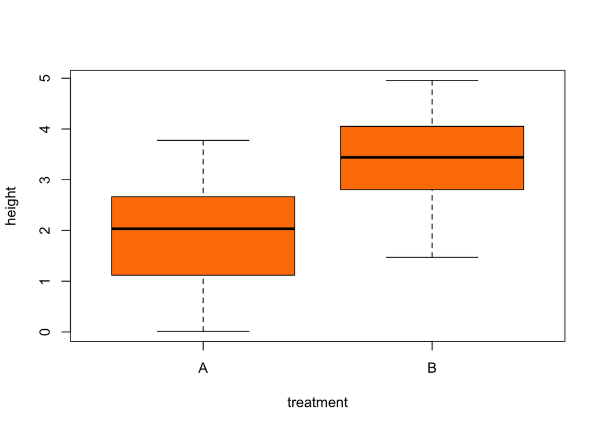

```r
boxplot(height~treatment, col = "darkorange1")
```

Also, *t tests* depend on two main assumptions: normality and variance homogeneity. To examine normality we will use the Shapiro-Wilk test and to examine variance homogeneity we will use the Bartlett test.

```r
shapiro.test(height)
```

```
##
##  Shapiro-Wilk normality test
##
## data:  height
## W = 0.97714, p-value = 0.07944
```

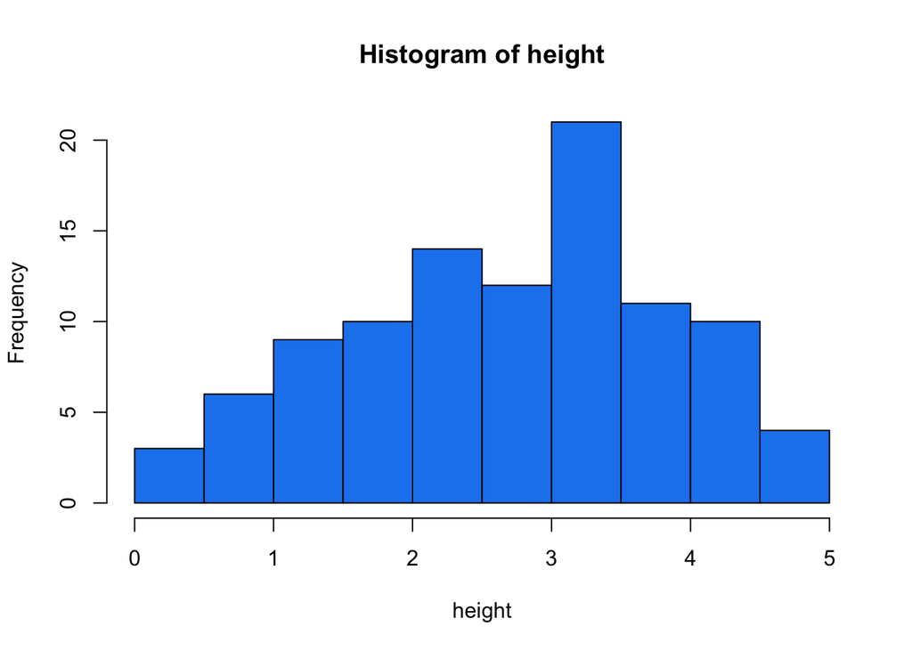

```r
hist(height, col = "dodgerblue2")
```

OK, our data is normal but has some deviations from the “ideal” normal curve. Let’s examine a Q-Q (quantile-quantile) plot to confirm this:

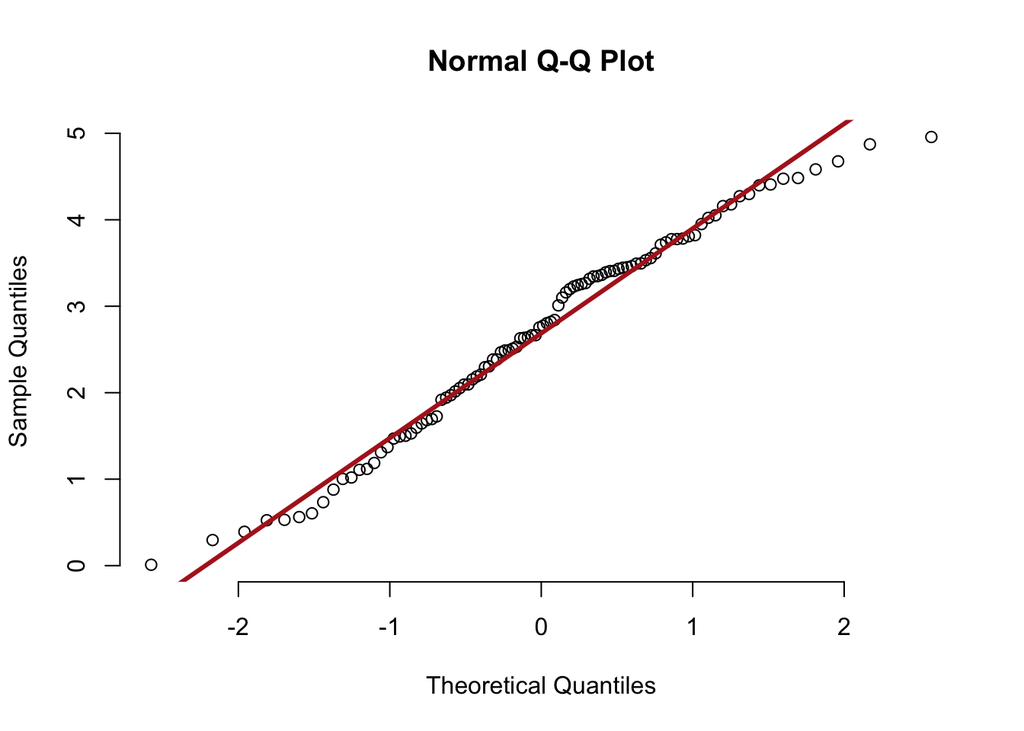

```r
qqnorm(data$height, pch = 1, frame = FALSE)
qqline(data$height, col = "firebrick", lwd = 3)
```

An ideal normal distribution will follow the red line.

And now, let’s test for **variance homogeneity**

```r
bartlett.test(height~treatment)
```

```
##
##  Bartlett test of homogeneity of variances
##
## data:  height by treatment
## Bartlett's K-squared = 0.95939, df = 1, p-value = 0.3273
```

What a relief! our data has homogeneous variances and therefore our results are reliable (failing to meet statistical assumptions would result in unreliable results).

### Non-parametric version

What if we fail to meet the normality assumption? Well, we can try a non-parametric version of the *t test* called Mann–Whitney–Wilcoxon, which can be summoned using the `wilcox.test` function.

```r
wilcox.test(height~treatment)
```

```
##
##  Wilcoxon rank sum test with continuity correction
##
## data:  height by treatment
## W = 359, p-value = 8.307e-10
## alternative hypothesis: true location shift is not equal to 0
```

The non-parametric test has confirmed our *t-test* results.

## More than two groups: the ANOVA test

What if instead two treatments we have three? One first though would be making three *t-tests* to compare treatment 1 vs 2, treatment 2 vs 3, and treatment 1 vs 3. But the **problem** here is that we have multiple comparisons upon the same data and therefore we will need apply some sort of correction to our significance values (e.g., a Bonferroni correction).

But, we have a more adequate option that is called Analysis of Variance (ANOVA) that can be called using the `aov` function in R. In this case, our null hypothesis would be:

$\mu {1} = \mu {2} = ... = \mu {n}$

To illustrate this, we will call our old friend, the *iris* dataset that has three species and some morphological measurements.

```r
data(iris)
attach(iris)
```

How sepal lenght differ among species? let’s make a simple boxplot:

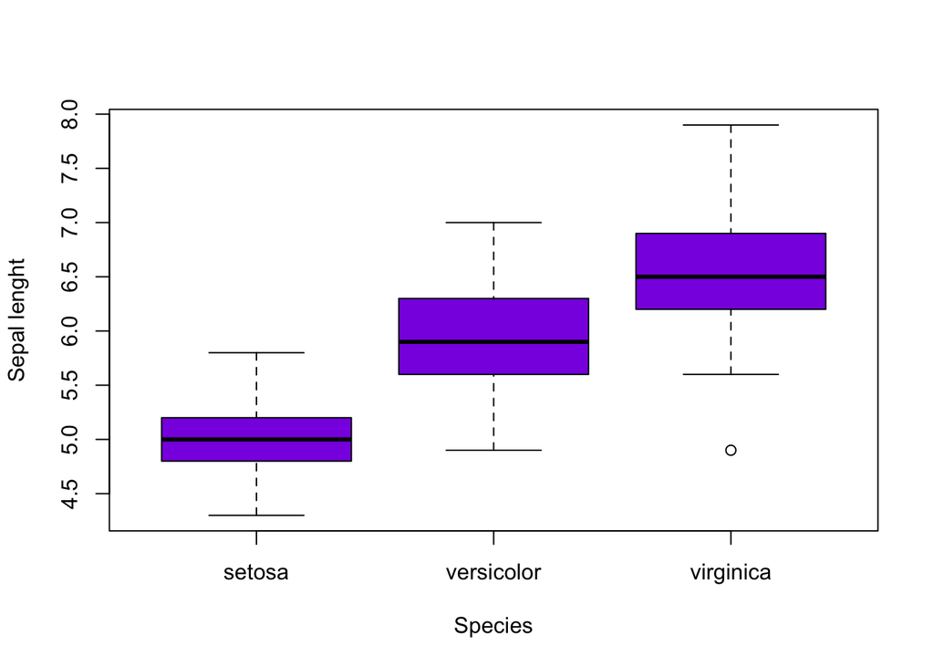

```r
boxplot(Sepal.Length~Species, col = "blueviolet", ylab= "Sepal lenght")
```

```r
comp1<-aov(Sepal.Length~Species)
summary(comp1)
```

```
##              Df Sum Sq Mean Sq F value Pr(>F)
## Species       2  63.21  31.606   119.3 <2e-16 ***
## Residuals   147  38.96   0.265
## ---
## Signif. codes:  0 '***' 0.001 '**' 0.01 '*' 0.05 '.' 0.1 ' ' 1
```

As we can suspect after examining the boxplot, there are significant differences here. ANOVA tests rely on the same assumptions than *t-tests* so let’s check normality and variance homogeneity:

```r
shapiro.test(Sepal.Length)
```

```
##
##  Shapiro-Wilk normality test
##
## data:  Sepal.Length
## W = 0.97609, p-value = 0.01018
```

Ouch! our response variable is not normal!

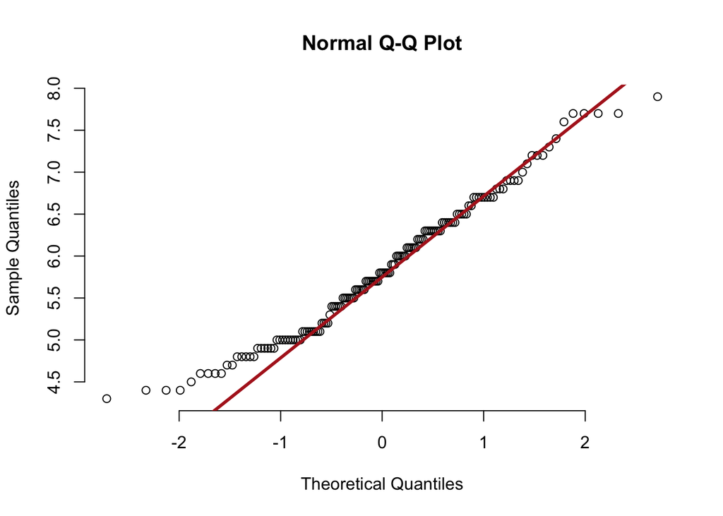

```r
qqnorm(iris$Sepal.Length, pch = 1, frame = FALSE)
qqline(iris$Sepal.Length, col = "firebrick", lwd = 3)
```

```r
bartlett.test(Sepal.Length~Species)
```

```
##
##  Bartlett test of homogeneity of variances
##
## data:  Sepal.Length by Species
## Bartlett's K-squared = 16.006, df = 2, p-value = 0.0003345
```

And also variances are not homogeneous. Therefore, our results may not be reliable.

### Non-parametric version

As for *t-test*, we have a non-parametric version of ANOVA called Kruskal-Wallis test, which can be executed with the function `kruskal.test`

```r
kruskal.test(Sepal.Length~Species)
```

```
##
##  Kruskal-Wallis rank sum test
##
## data:  Sepal.Length by Species
## Kruskal-Wallis chi-squared = 96.937, df = 2, p-value < 2.2e-16
```

## Categorical data: Chi-square and Fisher’s exact tests

So far, we have been comparing **means** of continuous variables across groups. But what if our response variable is **categorical** — for example, whether an individual survived or not, whether a plant was visited by a pollinator, or whether a species was detected at a given site? In those cases, we work with **counts** arranged in contingency tables, and we need different tools.

Both the `chi-square` test and `Fisher's exact test` ask the same question: **are two categorical variables independent of each other?** The **null hypothesis** is always that there is no association between them.

### Chi-square test

The chi-square test ($\chi^2$) compares **observed frequencies** against the **expected frequencies** under independence. It is appropriate for **large samples** where all expected cell counts are $\geq 5$.

Let’s use a biological example: we want to know whether the **presence of a parasitic mistletoe** (*Tristerix corymbosus*) is associated with the **type of host tree** (native vs. introduced). We sampled 120 trees and recorded whether each was infected or not.

```r
# Build the contingency table manually
mistletoe_table <- matrix(c(38, 12, 22, 48),
                          nrow = 2,
                          dimnames = list(
                            Host = c("Native", "Introduced"),
                            Infection = c("Infected", "Uninfected")
                          ))

mistletoe_table
```

```
##             Infection
## Host         Infected Uninfected
##   Native           38         22
##   Introduced       12         48
```

Let’s visualise the counts before running the test:

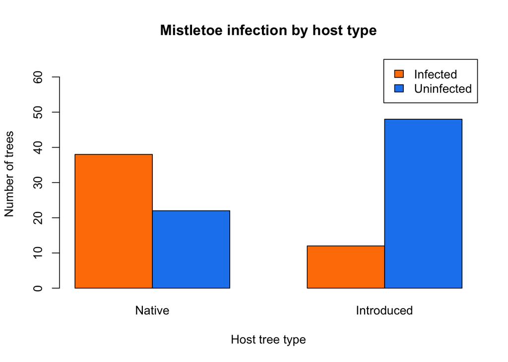

```r
barplot(t(mistletoe_table),
        beside = TRUE,
        col = c("darkorange1", "dodgerblue2"),
        legend.text = colnames(mistletoe_table),
        args.legend = list(x = "topright"),
        xlab = "Host tree type",
        ylab = "Number of trees",
        ylim = c(0,65),
        main = "Mistletoe infection by host type")
```

Now let’s run the chi-square test using the `chisq.test` function:

```r
chisq.test(mistletoe_table)
```

```
##
##  Pearson's Chi-squared test with Yates' continuity correction
##
## data:  mistletoe_table
## X-squared = 21.429, df = 1, p-value = 3.673e-06
```

The output gives us the $\chi^2$ statistic, degrees of freedom, and p-value. A significant result tells us that infection rates differ between host types — but not *how strong* the association is. For that, we can compute **Cramér’s V** as an effect size:

```r
# Cramér's V (requires the vcd package)
# install.packages("vcd")
library(vcd)
assocstats(mistletoe_table)
```

```
##                     X^2 df   P(> X^2)
## Likelihood Ratio 24.099  1 9.1500e-07
## Pearson          23.177  1 1.4774e-06
##
## Phi-Coefficient   : 0.439
## Contingency Coeff.: 0.402
## Cramer's V        : 0.439
```

Values of Cramér’s V near 0 indicate no association, while values near 1 indicate a very strong association.

We can also inspect whether expected cell counts meet the $\geq 5$ assumption:

```r
chisq.test(mistletoe_table)$expected
```

```
##             Infection
## Host         Infected Uninfected
##   Native           25         35
##   Introduced       25         35
```

All expected values are well above 5, so chi-square is appropriate here.

### Fisher’s Exact Test

Now suppose we have a **smaller dataset**: a field study where we only sampled 18 individuals of the marsupial *Dromiciops gliroides* and recorded whether each individual consumed mistletoe fruit (`Yes` / `No`) in two seasons (wet vs. dry). Small samples like this violate the chi-square assumption, so we use **Fisher’s exact test** instead, which computes the exact probability of the observed table (or a more extreme one) under the null hypothesis.

```r
# Build the contingency table
dromiciops_table <- matrix(c(7, 2, 3, 6),
                            nrow = 2,
                            dimnames = list(
                              Season = c("Wet", "Dry"),
                              Consumption = c("Yes", "No")
                            ))

dromiciops_table
```

```
##       Consumption
## Season Yes No
##    Wet   7  3
##    Dry   2  6
```

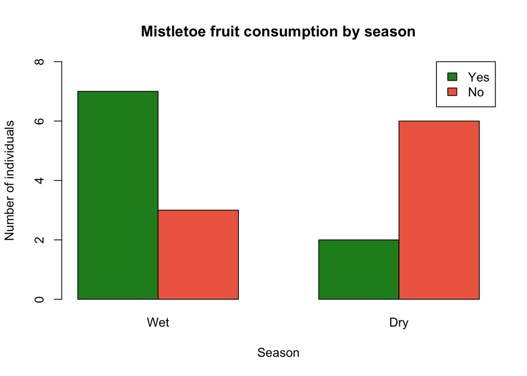

```r
barplot(t(dromiciops_table),
        beside = TRUE,
        col = c("forestgreen", "coral2"),
        legend.text = colnames(dromiciops_table),
        args.legend = list(x = "topright"),
        xlab = "Season",
        ylab = "Number of individuals",
        ylim = c(0,8),
        main = "Mistletoe fruit consumption by season")
```

Let’s check expected counts first to confirm chi-square would be inappropriate:

```r
chisq.test(dromiciops_table)$expected
```

```
##       Consumption
## Season Yes No
##    Wet   5  5
##    Dry   4  4
```

As expected, several cells fall below 5 — chi-square is not valid here. Let’s use Fisher’s exact test via `fisher.test`:

```r
fisher.test(dromiciops_table)
```

```
##
##  Fisher's Exact Test for Count Data
##
## data:  dromiciops_table
## p-value = 0.1534
## alternative hypothesis: true odds ratio is not equal to 1
## 95 percent confidence interval:
##    0.6218933 100.0509462
## sample estimates:
## odds ratio
##   6.176771
```

The output provides the exact p-value and, for 2×2 tables, an **odds ratio** with its confidence interval. An odds ratio > 1 means consumption was more likely in the wet season, while an odds ratio < 1 means the opposite.

### Quick comparison: when to use each?

| Situation | Use |
| --- | --- |
| Large sample, all expected counts ≥ 5 | Chi-square (`chisq.test`) |
| Small sample or any expected count < 5 | Fisher’s exact (`fisher.test`) |
| 2×2 table | Either; Fisher’s is always valid |
| Larger tables (e.g., 3×4) | Chi-square (Fisher’s becomes very slow) |
| Need effect size | Add Cramér’s V (chi-square) or odds ratio (Fisher’s) |

## Final thoughts

We have learned several simple methods for hypothesis testing today: *t-test*, ANOVA, chi-square, and Fisher’s exact test. The first two compare **means of continuous variables** across groups, while the last two are designed for **categorical (count) data** in contingency tables. All of these methods have their own assumptions and appropriate use cases, so choosing the right test for your data type is an essential first step in any analysis.

Licensing Creative Commons License

Licensed under a Creative Commons Attribution-ShareAlike 4.0 International License.  
2026 - Francisco E. Fontúrbel